# Financial Inclusion in Africa

Molo Muli

4/8/2021

# Research question and the data science problem

- The research question is anchored on the main objective of this project which is create a machine learning model that can predict which individuals are most likely to have or use a bank account.
- The data science problem will be a classification problem.
- My personal objective on this project is how to handle an imbalanced dataset in a classification problem

# Data Health and Preparation

No missing values are present in the dataset.

Half of the all respondents are of 35 years of age whereas 75% of all respondents are 49 years and below. Householdwise, the largest household consisted of 21 members given the average number being 4. On both variables, measures of spread indicated presence of outliers. Using Tukey’s rule of outlier detection, 2.77% of all observations had outliers. Given their marginal proportion, the outliers were dropped.

# Data Analysis

## Descriptive

On both the variables, the distribution is light tailed (platykurtic). Outliers, which were marginal in relative to the total sample were removed during the data wrangling process. Age has a high standard deviation indicating that values are spread out around the mean. Standard deviation (σ) as a measure of dispersion, its an indicator of how accurately the mean(μ) represents the sample data.

| variable | mean | sd | SEM | IQR | skewness | kurtosis | p25 | p50 | p75 | p100 |
| --- | --- | --- | --- | --- | --- | --- | --- | --- | --- | --- |
| Age | 38.21 | 15.63 | 0.10 | 22 | 0.72 | -0.28 | 26 | 35 | 48 | 81 |
| Household Size | 3.69 | 2.03 | 0.01 | 3 | 0.59 | -0.45 | 2 | 3 | 5 | 9 |

<sup>1</sup> **table 1 : Descritpive statistitcs of age and the household size**

Standard Error of the mean (SEM) on the other hand, measures how far the mean of the sample is likely to be from the true population mean. SEM is be inversely proportional to the sample size. As the sample size increases the mean value becomes more representative of the population, hence SEM reduces towards zero.

From *table one*, we can see that the SEM is more close to zero indicating that the mean of the sample close to the mean of the total sample. In deducing any of the coefficients mentioned above, primary assumption is that all observations from the sample are statistically independent.

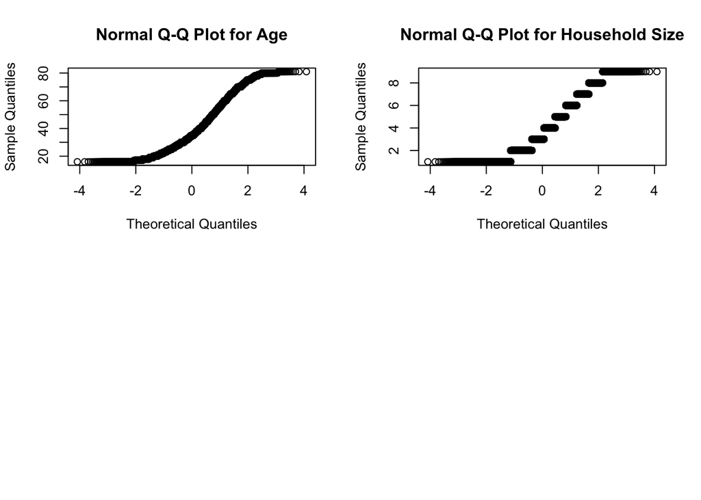

## Exploratory

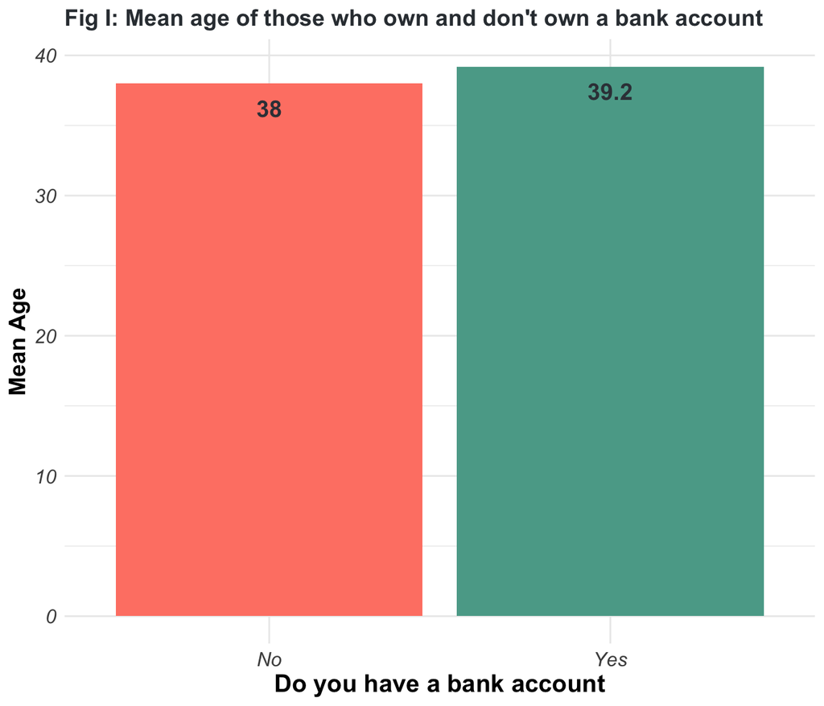

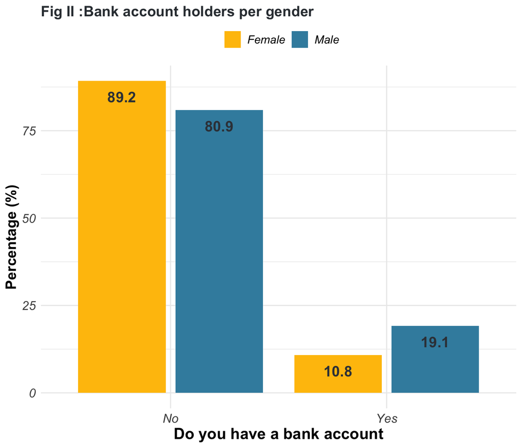

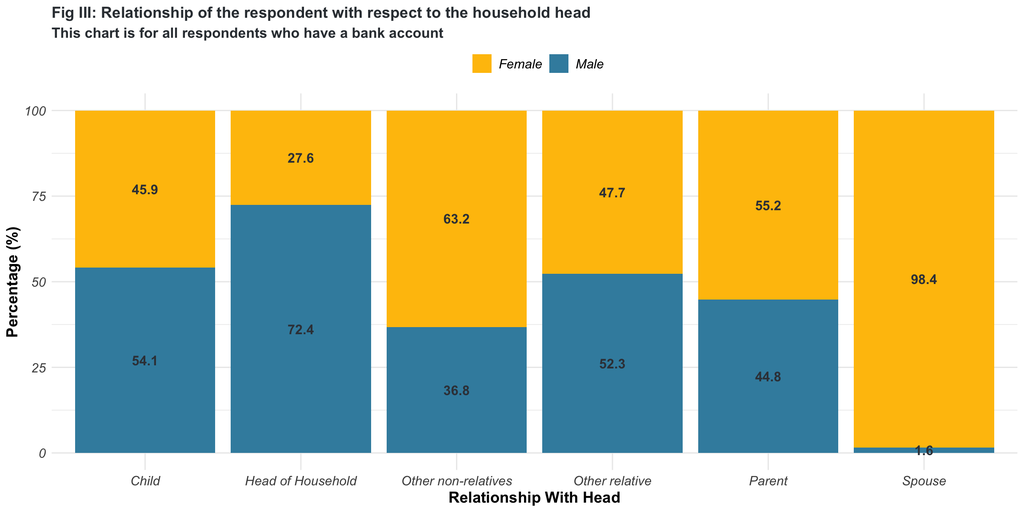

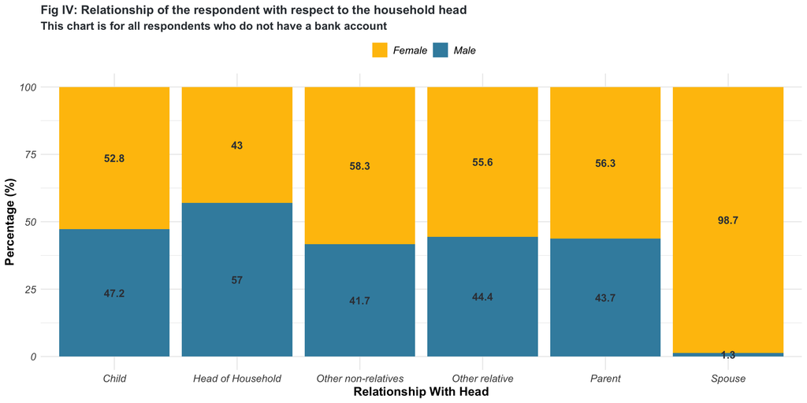

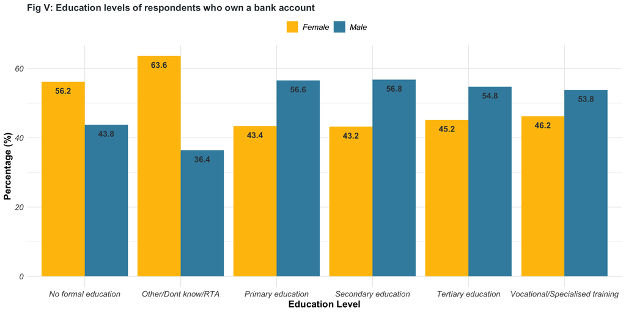

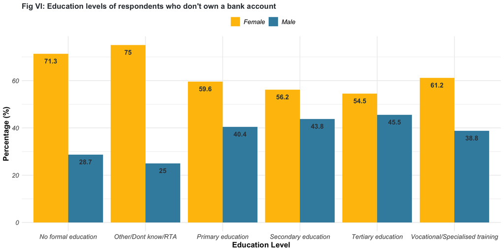

# Machine Learning

## Random Forests

### Random Forest Classifier

```r
# The classifier
set.seed(123)
model <- randomForest(formula = BankAccount ~ ., data = training)
model
```

```
##
## Call:
##  randomForest(formula = BankAccount ~ ., data = training)
##                Type of random forest: classification
##                      Number of trees: 500
## No. of variables tried at each split: 3
##
##         OOB estimate of  error rate: 11.42%
## Confusion matrix:
##       0    1 class.error
## 0 19099  485  0.02476511
## 1  2123 1121  0.65443896
```

From the model;

- Variables randomly selected at each split are 3.
- Out of the Bag error - a validation technique used in this model is 11.42%, hence the model has accuracy is 89%.
- Finally, below is a plot showing variable importance. Job type has the most predictive power. It’s closely followed by education level of a person and age.

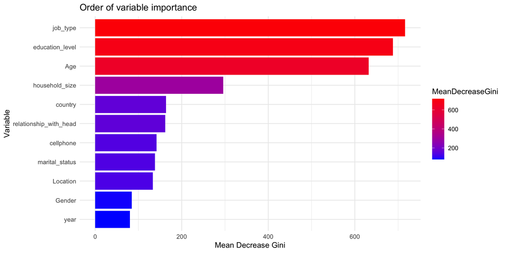

### Partial Dependence (DP) Plots

Partial Dependence plots (PDP) illustrate the relationship between an input variable and the response variable. They show how the predictions partially depend on values of the input. Useful to infer relationships between input variables and the predictor variables in complex non-parametric models.

The relationship can either be causal, (non)linear, monotonic, curvilinear, step function and so on. In our model we’ll illustrate PDP using the input that has the most predictive power (job type) and the response variable (presence of a bank account). Below are the PD plots for the 3 important variables against the predictor variable

#### PD plot of job title

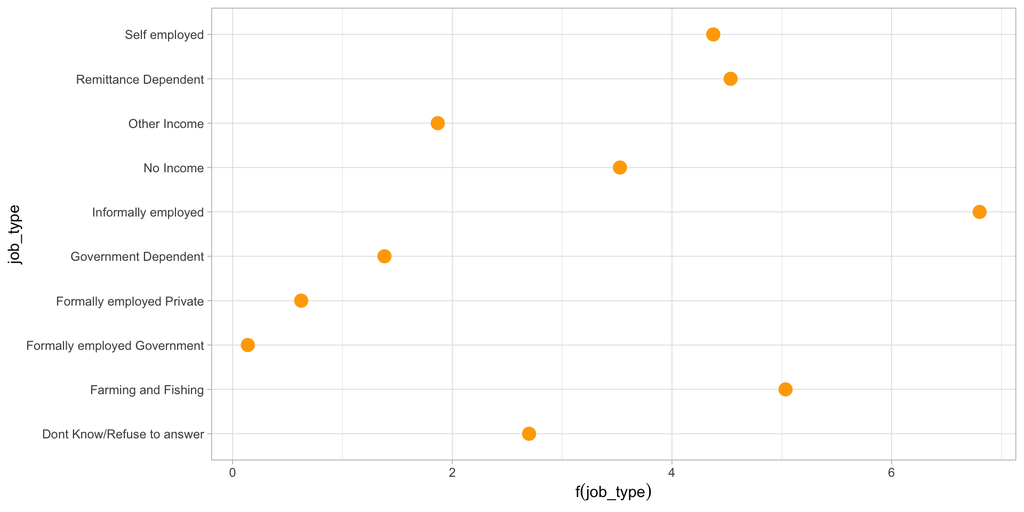

#### PD plot of education level

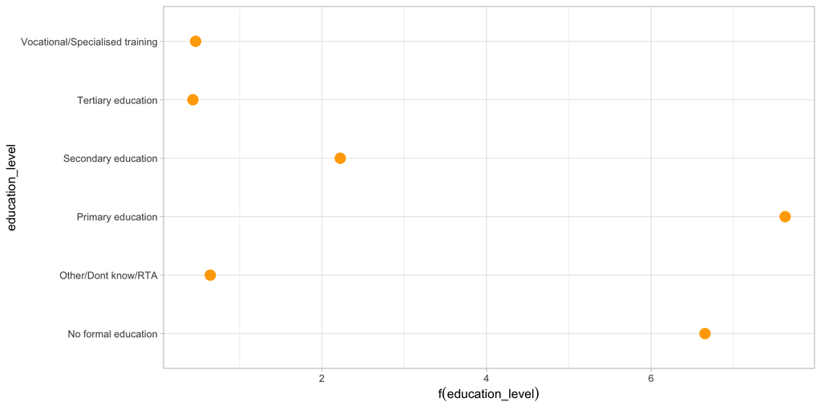

#### PD plot of age

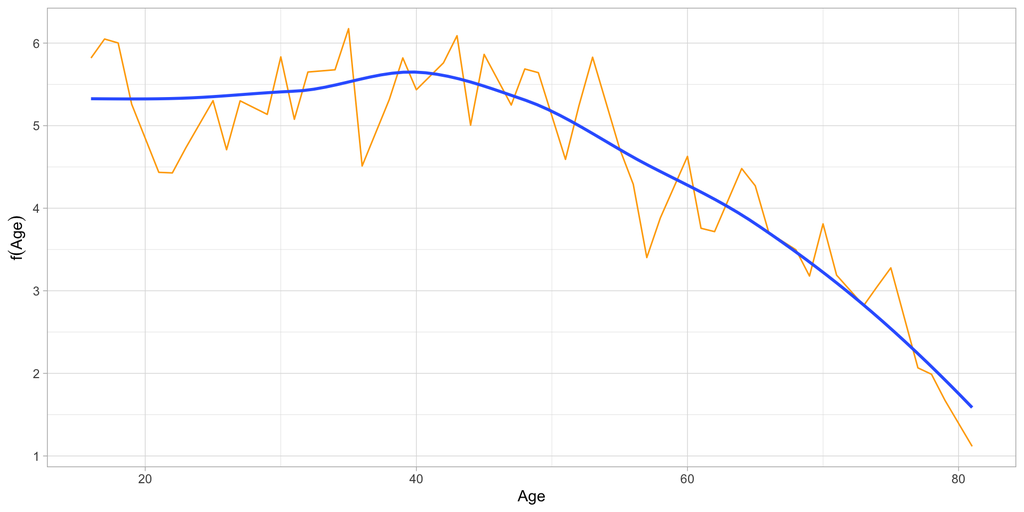

### Tuning the classifier

Hyperparameter tuning is usually treated as an optimization problem. Even though random forest is an out of the box algorithm, there are three important parameters that affect the accuracy of the model. These are `ntrees`, `mtry` and `sampsize`. `ntrees` is the number of trees in the forest. By default, its usually 500, `mtry` denotes the number of random predictor variables selected on each split and `sampsize` defaults to 63.2% of the training examples. Reason for the explicit proportion is because 63.2% is the expected number of unique observations in a bootstrap sample. Other hyper parameters that affect the performance of a model include:

- `nodesize` - When the nodesize is small, it allows deeper more complex trees to be grown.
- `maxnodes` - Together with `ntrees`, it limits the tree growth to avoid overfitting.

```
## mtry = 3  OOB error = 11.49%
## Searching left ...
## mtry = 2     OOB error = 11.42%
## 0.006481128 0.01
## Searching right ...
## mtry = 6     OOB error = 12.34%
## -0.07396111 0.01
```

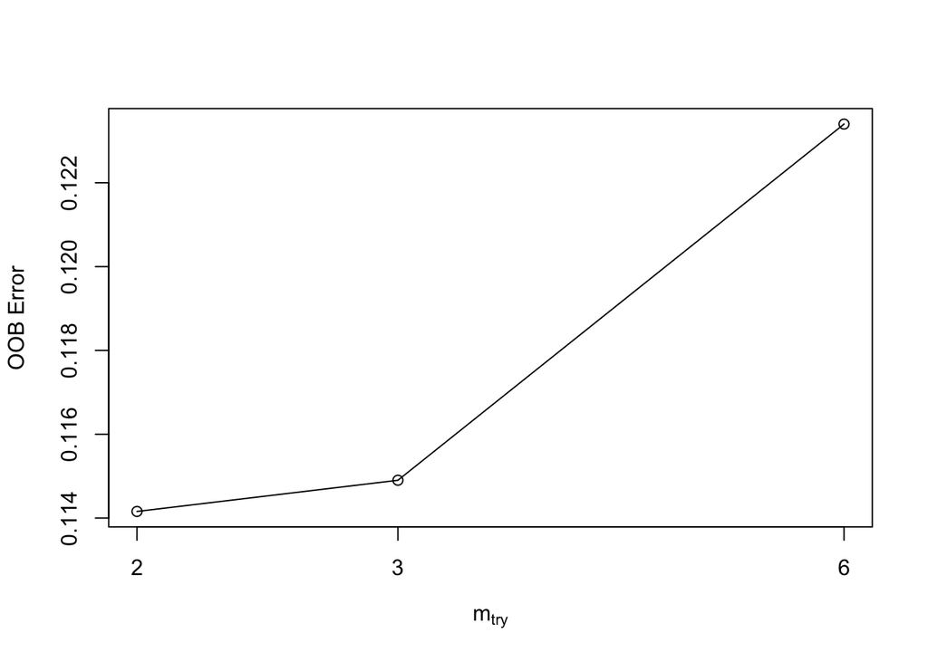

```r
# Tuning mtry using out of bag (OOB) error
tune_mtry <- tuneRF(training[,1:11],
                    training$BankAccount,
                    ntreeTry = 500,
                    stepFactor = 2,
                    plot = T,
                    trace = T,
                    # doBest = T,
                    improve = 0.01)
```

```r
tune_mtry
```

```
##       mtry  OOBError
## 2.OOB    2 0.1141581
## 3.OOB    3 0.1149028
## 6.OOB    6 0.1234011
```

- `mtry` is 2 because it has the least OOB error. Very marginal with three.

Pruning the trees in a random forest model is taken care of using bootstrapping. Samples used to train the individual trees are “bootstrapped”. Given that the random trees have random features, there might be very marginal (if any) correlation between the trees.